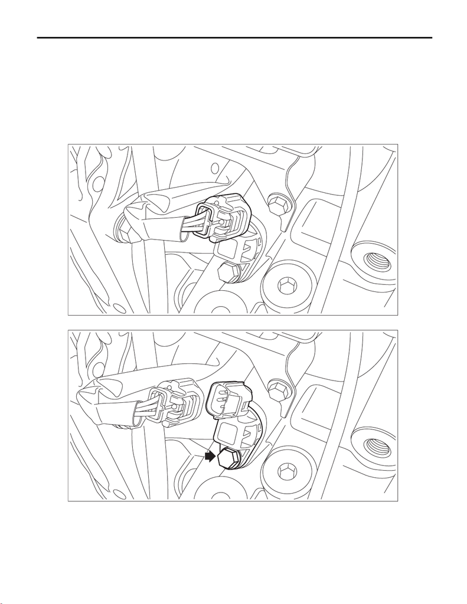

CVT(TR690)-102

Primary Speed Sensor

CONTINUOUSLY VARIABLE TRANSMISSION

16.Primary Speed Sensor

A: REMOVAL

CAUTION:

Be sure to prevent water or oil from contacting the connector terminal of primary speed sensor. If ad-

hesion occurs, replace with a new part.

1) Disconnect the ground terminal from battery sensor. <Ref. to NT-5, BATTERY, NOTE, Note.>

2) Remove the intercooler. <Ref. to IN(w/o STI)-38, REMOVAL, Intercooler.>

3) Clean the transmission exterior.

4) Remove the primary speed sensor harness connector.

5) Remove the primary speed sensor and the spacer.

AT-07735

AT-07837

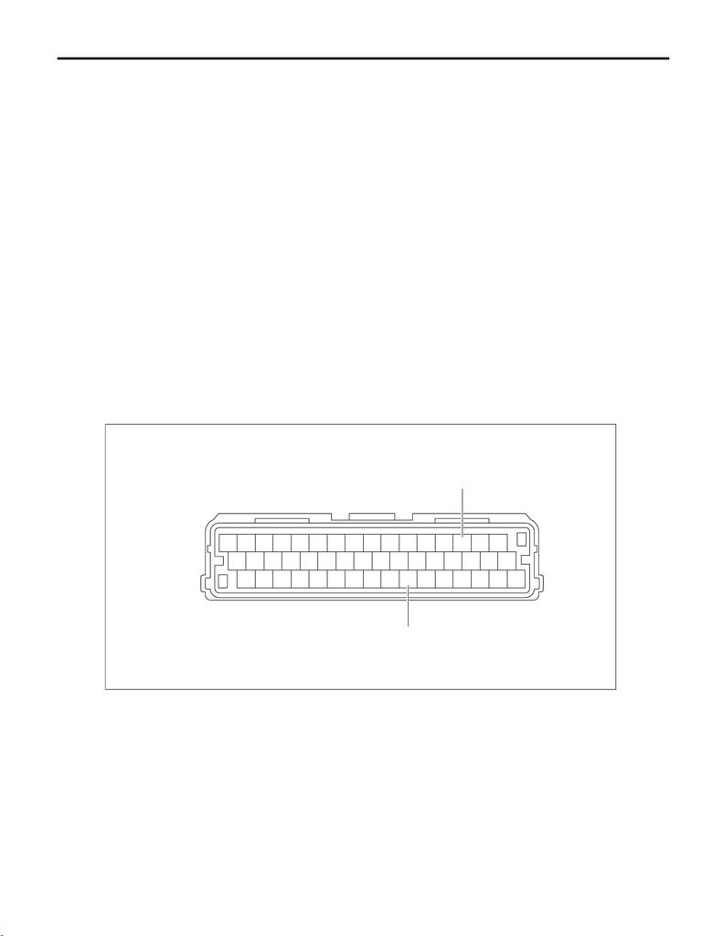

CVT(TR690)-103

Primary Speed Sensor

CONTINUOUSLY VARIABLE TRANSMISSION

B: INSTALLATION

CAUTION:

Be sure to prevent water or oil from contacting the connector terminal of primary speed sensor. If ad-

hesion occurs, replace with a new part.

Install in the reverse order of removal.

CAUTION:

Do not forget to install the spacer.

NOTE:

• Use new O-rings.

• Apply CVTF to the O-rings.

Tightening torque:

Primary speed sensor

5 N·m (0.5 kgf-m, 3.7 ft-lb)

C: INSPECTION

1) Remove the bulkhead harness connector from TCM. <Ref. to CVT(TR690)-126, REMOVAL, Transmis-

sion Control Module (TCM).>

2) Set the ST between the TCM and bulkhead harness.

ST 18460AA040 CHECK BOARD

3) Set the probe of oscilloscope to the check board connector.

Terminals:

No. 14 (+) — No. 42 (–)

(A) + probe

(B) – probe

123456789

10 11 12 13 14 15 16

17 18 19 20 21 22 23 24 25 26 27 28 29 30 31 32

33 34 35 36 37 38 39 40 41 42 43 44 45 46 47 48

(A)

CVT00511

(B)

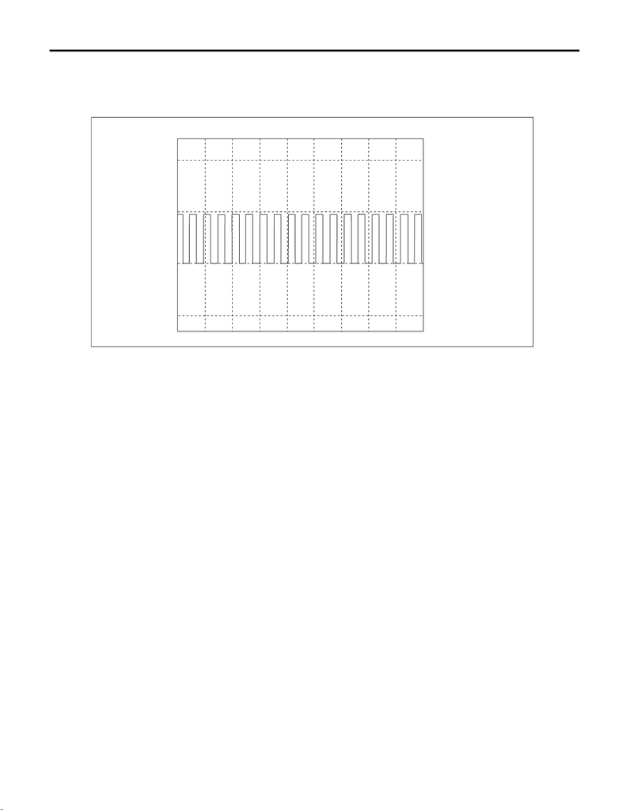

CVT(TR690)-104

Primary Speed Sensor

CONTINUOUSLY VARIABLE TRANSMISSION

4) Start and warm up the engine.

5) Check the waveform of primary speed sensor with engine idling.

NOTE:

The waveform cycle changes as the speed changes.

AT-08034

0

5

-5

10

(V)